# PDL-churn

##### 'Internet Service' a un impact sur le taux de désabonnement. Les clients de la fibre optique sont plus susceptibles de chuter.

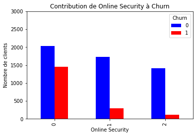

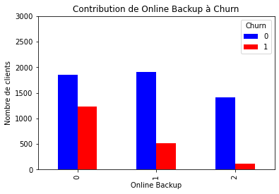

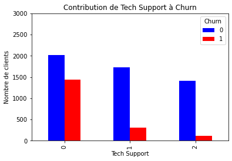

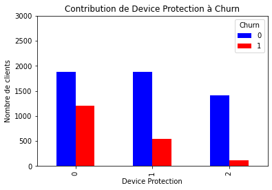

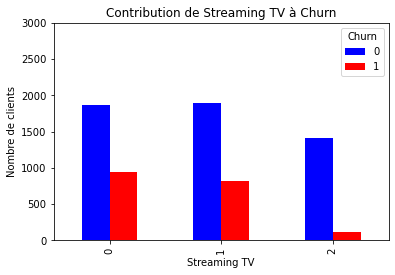

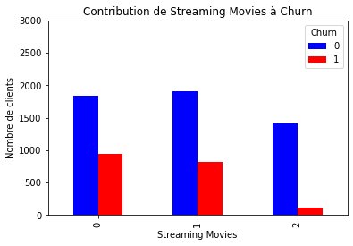

```python
columns= ['Online Security', 'Online Backup','Tech Support', 'Device Protection', 'Streaming TV', 'Streaming Movies' ]
for col in columns:
    # Créer une nouvelle figure avec une taille de 8x6 pouces
    plt.figure(figsize=(8, 6))

    # Create a contingency table of Tech Support and Churn
    contingency_table = pd.crosstab(churn_c[col], churn_c['Churn'])

    # Afficher le tableau en un graphique en barres
    contingency_table.plot.bar(color=['blue', 'red'])
    plt.title(f"Contribution de {col} à Churn")
    plt.xlabel(f"{col}")
    plt.ylabel('Nombre de clients')
    plt.ylim([0, 3000])

    plt.show()
```

###### 'Online Security' semble être une caractéristique importante. Les clients sans sécurité en ligne sont plus susceptibles de chuter.

##### Le manque de support technique ('Tec Support'), de services de sauvegarde en ligne ('Online Backup'), de protection de l'appareil ('Device Protection'), de Streaming TV et de Streaming Movies augmentent la probabilité de désabonnement.

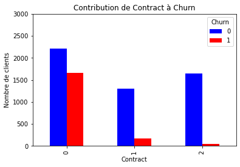

```python
# Créer une nouvelle figure avec une taille de 8x6 pouces
plt.figure(figsize=(8, 6))

# Create a contingency table of Contract and Churn
contingency_table = pd.crosstab(churn_c['Contract'], churn_c['Churn'])

# Afficher le tableau en un graphique en barres
contingency_table.plot.bar(color=['blue', 'red'])
plt.title("Contribution de Contract à Churn")
plt.xlabel("Contract")
plt.ylabel('Nombre de clients')
plt.ylim([0, 3000])

plt.show()
```

###### 'Contract' semble être une caractéristique importante. Les clients de 'month-to-month' sont plus susceptibles de chuter.

[figure not shown]

```python
# Créer une nouvelle figure avec une taille de 8x6 pouces
plt.figure(figsize=(8, 6))

# Créer contingency table de Paperless Billing et Churn
contingency_table = pd.crosstab(churn_c['Paperless Billing'], churn_c['Churn'])

# Visualiser la contribution de Paperless Billing à Churn, pour Churn = 0 et Churn = 1
churn_0 = contingency_table.loc[0, :]
churn_1 = contingency_table.loc[1, :]

plt.subplot(1, 2, 1)
churn_0.plot(kind='bar', color='blue')
plt.title('Churn = 0')
plt.xlabel('Paperless Billing')
plt.ylabel('Number of Customers')
plt.ylim([0, 3000])

plt.subplot(1, 2, 2)
churn_1.plot(kind='bar', color='red')
plt.title('Churn = 1')
plt.xlabel('Paperless Billing')
plt.ylim([0, 3000])
plt.gca().axes.yaxis.set_ticklabels([]) # disable y-axis tick labels

plt.subplots_adjust(wspace=0)
plt.show()
```

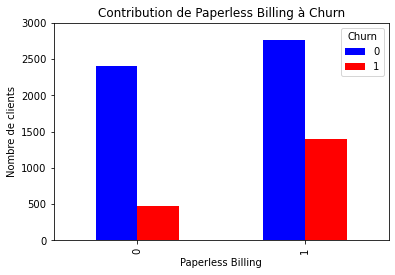

```python
# Créer une nouvelle figure avec une taille de 8x6 pouces
plt.figure(figsize=(8, 6))

# Create a contingency table of Paperless Billing and Churn
contingency_table = pd.crosstab(churn_c['Paperless Billing'], churn_c['Churn'])

# Afficher le tableau en un graphique en barres
contingency_table.plot.bar(color=['blue', 'red'])
plt.title("Contribution de Paperless Billing à Churn")
plt.xlabel("Paperless Billing")
plt.ylabel('Nombre de clients')
plt.ylim([0, 3000])

plt.show()
```

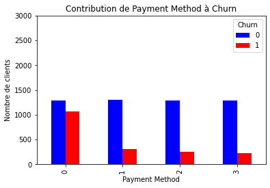

```python
# Créer une nouvelle figure avec une taille de 8x6 pouces
plt.figure(figsize=(8, 6))

# Create a contingency table of Payment Method and Churn
contingency_table = pd.crosstab(churn_c['Payment Method'], churn_c['Churn'])

# Afficher le tableau en un graphique en barres
contingency_table.plot.bar(color=['blue', 'red'])
plt.title("Contribution de Payment Method à Churn")
plt.xlabel("Payment Method")
plt.ylabel('Nombre de clients')
plt.ylim([0, 3000])

plt.show()
```

###### 'Payment Method' semble être une caractéristique importante. Les clients qui paye en 'Electronic check' sont plus susceptibles de chuter.

```
processing with Tenure Months
```

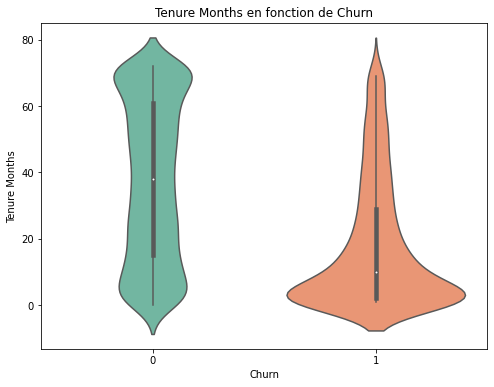

```
processing with Total Charges
```

[figure not shown]

```
processing with Monthly Charges
```

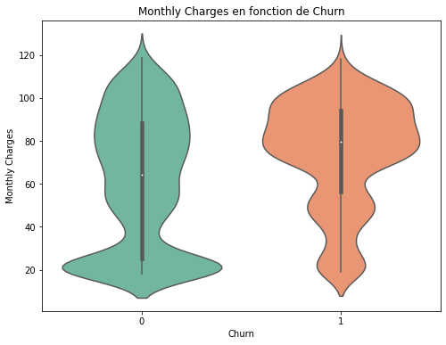

```python
columns=['Tenure Months','Total Charges', 'Monthly Charges']

for col in columns:
    print(f"processing with {col}")
    # Créer une nouvelle figure avec une taille de 8x6 pouces
    plt.figure(figsize=(8, 6))

    # Créer un violinplot de la variable en fonction de 'Churn'
    sns.violinplot(x='Churn', y=col, data=churn_c, palette='Set2')

    # Définir les titres et les étiquettes des axes
    plt.title(f"{col} en fonction de Churn")
    plt.xlabel('Churn')
    plt.ylabel(f"{col}")

    plt.show()
```

```python
churn_c['Total Charges'].info
```

```
<bound method Series.info of 0        108.15
1        151.65
2         820.5
3       3046.05
4        5036.3
         ...
7038     1419.4
7039     1990.5
7040     7362.9
7041     346.45
7042     6844.5
Name: Total Charges, Length: 7043, dtype: object>
```

```python
# Convertir la colonne 'Total Charges' en type de données numériques
churn_c['Total Charges'] = pd.to_numeric(churn_c['Total Charges'], errors='coerce')
```

```python
churn_c['Total Charges'].info
```

```
<bound method Series.info of 0        108.15
1        151.65
2        820.50
3       3046.05
4       5036.30
         ...
7038    1419.40
7039    1990.50
7040    7362.90
7041     346.45
7042    6844.50
Name: Total Charges, Length: 7043, dtype: float64>
```

```
processing with Tenure Months
```

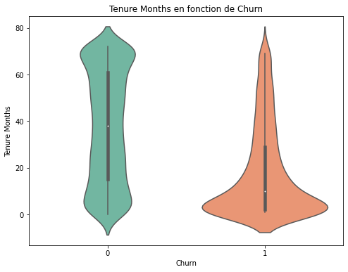

```
processing with Total Charges
```

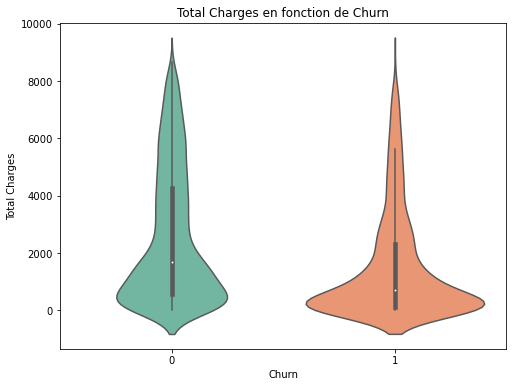

```
processing with Monthly Charges
```

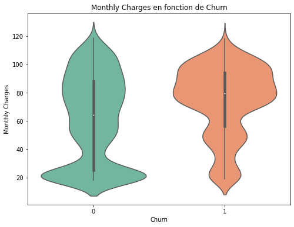

```python
columns=['Tenure Months','Total Charges', 'Monthly Charges']

for col in columns:
    print(f"processing with {col}")
    # Créer une nouvelle figure avec une taille de 8x6 pouces
    plt.figure(figsize=(8, 6))

    # Créer un violinplot de la variable en fonction de 'Churn'
    sns.violinplot(x='Churn', y=col, data=churn_c, palette='Set2')

    # Définir les titres et les étiquettes des axes
    plt.title(f"{col} en fonction de Churn")
    plt.xlabel('Churn')
    plt.ylabel(f"{col}")

    plt.show()
```

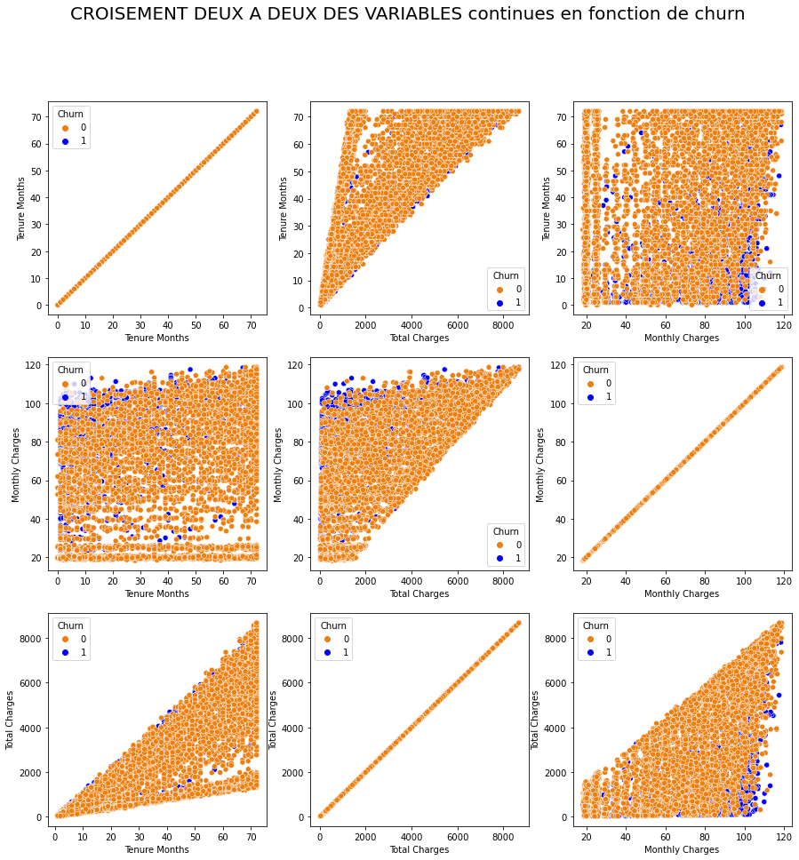

```python
# Définir les variables continues
columns=['Tenure Months', 'Monthly Charges','Total Charges']

# Définir la palette de couleurs pour les points
my_palette = sns.color_palette(["#ED7F10","#0000FF"])

# Définir la grille de graphiques
fig, axes = plt.subplots(nrows=3, ncols=3, figsize=(15, 15))

# Parcourir les colonnes et les sous-tracés
for i, col in enumerate(columns):
    sns.scatterplot(x='Tenure Months', y=col, hue='Churn', data=churn_c,  ax=axes[i, 0], palette=my_palette)
    sns.scatterplot(x='Monthly Charges', y=col, hue='Churn', data=churn_c, ax=axes[i, 2], palette=my_palette)
    sns.scatterplot(x='Total Charges', y=col, hue='Churn', data=churn_c,  ax=axes[i, 1], palette=my_palette)

# Ajouter un titre pour la grille de graphiques
fig.suptitle('CROISEMENT DEUX A DEUX DES VARIABLES continues en fonction de churn', fontsize=20)

# Afficher la grille de graphiques
plt.show()
```

### Observation

- Les clients à faible 'Tenure Months' sont beaucoup plus susceptibles de se désister
- Dans le même temps, les clients qui n'ont pas churn sont répartis sur un large éventail de 'Tenure Months'
- les 'Monthly Charges' ont un impact significatif sur la décision des clients de 'Churn'
- Les clients avec des 'Monthly Charges' élevés sont beaucoup plus susceptibles de 'churn' que les clients avec un faible montant de 'Monthly Charges'. En revanche, les clients dont les 'Monthly Charges' sont bas sont plus susceptibles de 'no Churn'.
- Les personnes ayant une ancienneté inférieure et des frais mensuels plus élevés ont tendance à se désister davantage.
- Avoir un contrat mensuel et un Internet par fibre optique ont un effet vraiment énorme sur la probabilité de désabonnement.

```python
churn_c.info()
```

```
<class 'pandas.core.frame.DataFrame'>
RangeIndex: 7043 entries, 0 to 7042
Data columns (total 25 columns):
 #   Column             Non-Null Count  Dtype
---  ------             --------------  -----
 0   City               7043 non-null   object
 1   Zip Code           7043 non-null   int64
 2   Gender             7043 non-null   int64
 3   Senior Citizen     7043 non-null   int64
 4   Partner            7043 non-null   int64
 5   Dependents         7043 non-null   int64
 6   Tenure Months      7043 non-null   int64
 7   Phone Service      7043 non-null   int64
 8   Multiple Lines     7043 non-null   int64
 9   Internet Service   7043 non-null   int64
```

[output cut: 17 more lines]

```python
#supprimer la colonne City, Churn Value, Churn Score, CLTV
churn_c = churn_c.drop('City', axis=1)
churn_c = churn_c.drop('Churn Value', axis=1)
churn_c = churn_c.drop('Churn Score', axis=1)
churn_c = churn_c.drop('CLTV', axis=1)
```

```python
churn_c.info()
```

```
<class 'pandas.core.frame.DataFrame'>
RangeIndex: 7043 entries, 0 to 7042
Data columns (total 21 columns):
 #   Column             Non-Null Count  Dtype
---  ------             --------------  -----
 0   Zip Code           7043 non-null   int64
 1   Gender             7043 non-null   int64
 2   Senior Citizen     7043 non-null   int64
 3   Partner            7043 non-null   int64
 4   Dependents         7043 non-null   int64
 5   Tenure Months      7043 non-null   int64
 6   Phone Service      7043 non-null   int64
 7   Multiple Lines     7043 non-null   int64
 8   Internet Service   7043 non-null   int64
 9   Online Security    7043 non-null   int64
 10  Online Backup      7043 non-null   int64
 11  Device Protection  7043 non-null   int64
 12  Tech Support       7043 non-null   int64
 13  Streaming TV       7043 non-null   int64
 14  Streaming Movies   7043 non-null   int64
 15  Contract           7043 non-null   int64
 16  Paperless Billing  7043 non-null   int64
 17  Payment Method     7043 non-null   int64
 18  Monthly Charges    7043 non-null   float64
 19  Total Charges      7032 non-null   float64
 20  Churn              7043 non-null   int64
dtypes: float64(2), int64(19)
memory usage: 1.1 MB
```

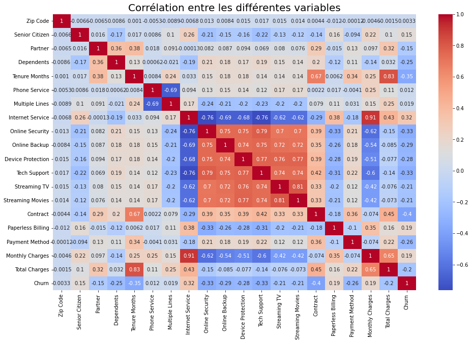

```python
# Sélectionner les variables numériques
columns = ['Zip Code', 'Senior Citizen', 'Partner', 'Dependents', 'Tenure Months',
            'Phone Service', 'Multiple Lines', 'Internet Service', 'Online Security',
            'Online Backup', 'Device Protection', 'Tech Support', 'Streaming TV',
            'Streaming Movies', 'Contract', 'Paperless Billing', 'Payment Method',
            'Monthly Charges', 'Total Charges', 'Churn']

# Calculer la matrice de corrélation
corr = churn_c[columns].corr()

# Créer une heatmap de corrélation
plt.figure(figsize=(16, 10))
sns.heatmap(corr, annot=True, cmap='coolwarm')
plt.title('Corrélation entre les différentes variables', fontsize=20)
plt.show()
```

```
1. Total Charges (0.149043)
2. Tenure Months (0.138409)
3. Monthly Charges (0.136153)
4. Zip Code (0.130171)
5. Contract (0.076540)
6. Payment Method (0.049394)
7. Online Security (0.038835)
8. Dependents (0.034291)
9. Tech Support (0.034002)
10. Internet Service (0.033925)
11. Gender (0.022641)
12. Online Backup (0.022517)
13. Partner (0.020735)
14. Paperless Billing (0.020631)
15. Device Protection (0.020513)
16. Multiple Lines (0.019075)
17. Senior Citizen (0.017221)
18. Streaming TV (0.016112)
19. Streaming Movies (0.015738)
20. Phone Service (0.004054)
```

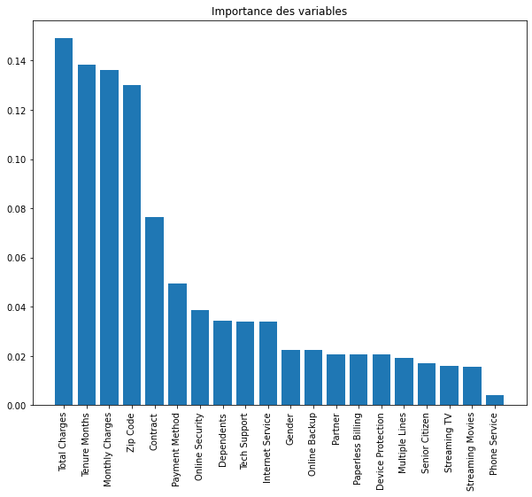

```python
from sklearn.ensemble import RandomForestClassifier

churn_c = churn_c.fillna(churn_c.mean())

# Séparer les données en variables indépendantes (X) et dépendante (y)
X = churn_c.iloc[:, :-1] # toutes les colonnes sauf la dernière (Churn)
y = churn_c.iloc[:, -1] # la dernière colonne (Churn)

# Instancier le classifieur
rfc = RandomForestClassifier(random_state=42)

# Ajuster le modèle aux données
rfc.fit(X, y)

# Extraire l'importance de chaque variable
importances = rfc.feature_importances_

# Trier les indices des variables par ordre décroissant d'importance
indices = np.argsort(importances)[::-1]


# Afficher les noms des variables et leur importance
for f in range(X.shape[1]):
    print("%d. %s (%f)" % (f + 1, X.columns[indices[f]], importances[indices[f]]))

# Afficher le graphique d'importance de chaque variable
plt.figure(figsize=(10,8))
plt.title("Importance des variables")
plt.bar(range(X.shape[1]), importances[indices])
plt.xticks(range(X.shape[1]), X.columns[indices], rotation=90)
plt.show()
```

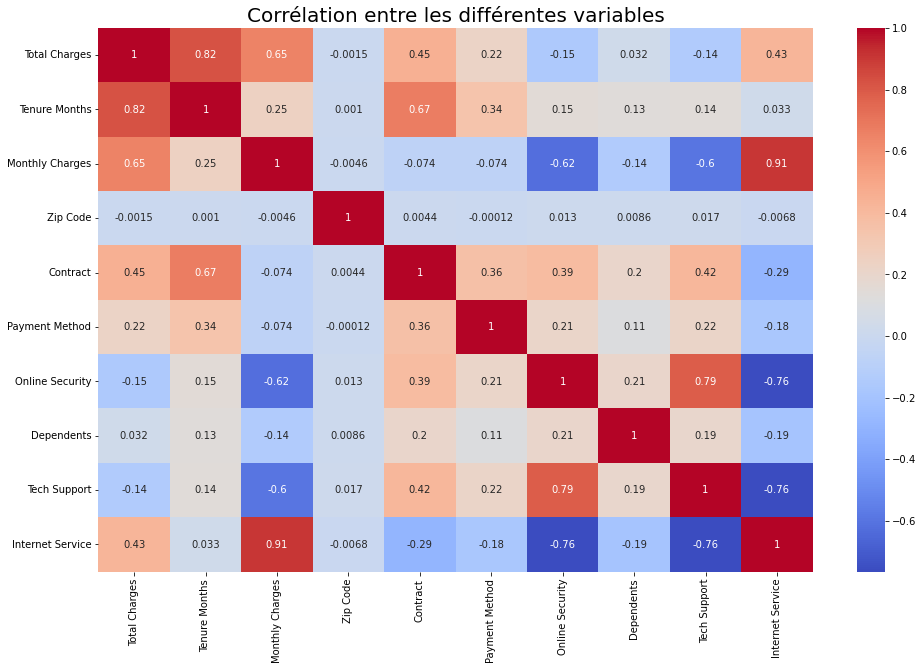

```python
# Sélectionner les variables numériques
columns = ['Total Charges', 'Tenure Months', 'Monthly Charges', 'Zip Code', 'Contract', 'Payment Method',
           'Online Security', 'Dependents', 'Tech Support', 'Internet Service' ]

# Calculer la matrice de corrélation
corr = churn_c[columns].corr()

# Créer une heatmap de corrélation
plt.figure(figsize=(16, 10))
sns.heatmap(corr, annot=True, cmap='coolwarm')
plt.title('Corrélation entre les différentes variables', fontsize=20)
plt.show()
```

```
1. Total Charges (0.15)
2. Tenure Months (0.14)
3. Monthly Charges (0.14)
4. Zip Code (0.13)
5. Contract (0.08)
6. Payment Method (0.05)
7. Online Security (0.04)
8. Dependents (0.03)
9. Tech Support (0.03)
10. Internet Service (0.03)
11. Gender (0.02)
12. Online Backup (0.02)
13. Partner (0.02)
14. Paperless Billing (0.02)
15. Device Protection (0.02)
16. Multiple Lines (0.02)
17. Senior Citizen (0.02)
18. Streaming TV (0.02)
19. Streaming Movies (0.02)
20. Phone Service (0.00)
```

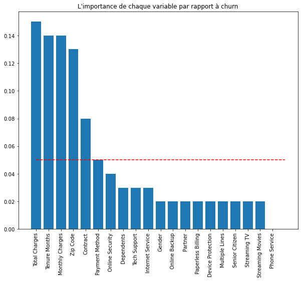

```python
from sklearn.ensemble import RandomForestClassifier

churn_c = churn_c.fillna(churn_c.mean())

# Séparer les données en variables indépendantes (X) et dépendante (y)
X = churn_c.iloc[:, :-1] # toutes les colonnes sauf la dernière (Churn)
y = churn_c.iloc[:, -1] # la dernière colonne (Churn)

# Instancier le classifieur
rfc = RandomForestClassifier(random_state=42)

# Ajuster le modèle aux données
rfc.fit(X, y)

# Extraire l'importance de chaque variable
importances = rfc.feature_importances_

# Trier les indices des variables par ordre décroissant d'importance
indices = np.argsort(importances)[::-1]

# Afficher les noms des variables et leur importance, en arrondissant à 2 chiffres après la virgule
for f in range(X.shape[1]):
    print("%d. %s (%.2f)" % (f + 1, X.columns[indices[f]], importances[indices[f]]))

# Afficher le graphique d'importance de chaque variable, en arrondissant à 2 chiffres après la virgule
plt.figure(figsize=(10,8))
plt.title("L'importance de chaque variable par rapport à churn")
plt.bar(range(X.shape[1]), np.round(importances[indices], 2))
plt.xticks(range(X.shape[1]), X.columns[indices], rotation=90)
plt.plot([0,X.shape[1]],[0.05,0.05],'r--')
plt.show()
```

```python
!jupyter nbconvert --to html PDL-churn.ipynb
```

```
[NbConvertApp] Converting notebook PDL-churn.ipynb to html
[NbConvertApp] Writing 2793016 bytes to PDL-churn.html
```